3. 회귀나무 (Regression Tree)
- tree library를 이용한 회귀나무 모델

```r
library(tree)
tree.fit <- tree(train_y ~ ., data=traindat)
tree.fit
```

```
## node), split, n, deviance, yval
##       * denotes terminal node
##
##  1) root 374 207.800 15.14
##    2) yuheung < 16.7776 275 117.400 14.92
##      4) sukbak < 21.5919 249  93.630 14.85
##        8) specialsch < 0.5 228  87.530 14.88 *
##        9) specialsch > 0.5 21   3.992 14.55 *
##      5) sukbak > 21.5919 26  10.690 15.60 *
##    3) yuheung > 16.7776 99  39.840 15.76
##      6) school < 1.80498 79  30.090 15.88
##       12) yuheung < 104.162 60  22.560 15.79
##         24) sukbak < 5.25189 17   3.353 16.17 *
##         25) sukbak > 5.25189 43  15.850 15.64
##           50) yuheung < 22.6084 7   3.981 16.14 *
##           51) yuheung > 22.6084 36   9.784 15.55 *
##       13) yuheung > 104.162 19   5.430 16.17 *
##      7) school > 1.80498 20   3.330 15.25 *
```

```r
summary(tree.fit)
```

```
##
## Regression tree:
## tree(formula = train_y ~ ., data = traindat)
## Variables actually used in tree construction:
## [1] "yuheung"    "sukbak"     "specialsch" "school"
## Number of terminal nodes:  8
## Residual mean deviance:  0.35 = 128.1 / 366
## Distribution of residuals:
##     Min.  1st Qu.   Median     Mean  3rd Qu.     Max.
## -2.91700 -0.30140  0.01296  0.00000  0.28350  1.88900
```

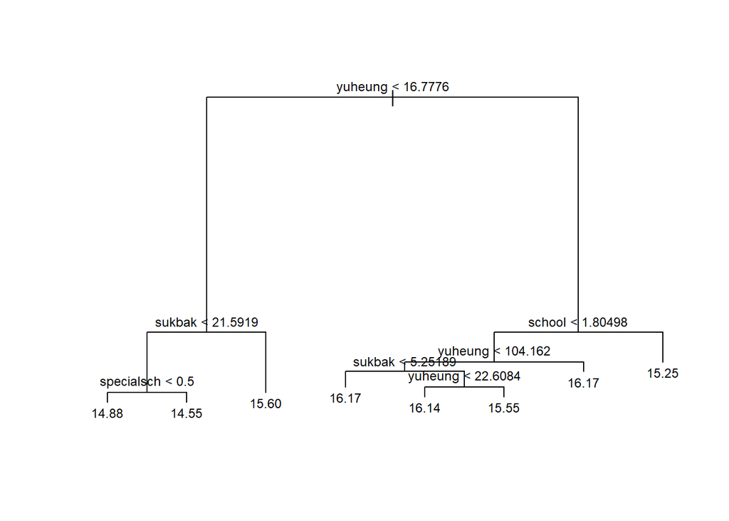

```r
tree.pred <- predict(tree.fit, testdat)
mean((tree.pred - testdat$test_y)^2)
```

```
## [1] 0.4290245
```

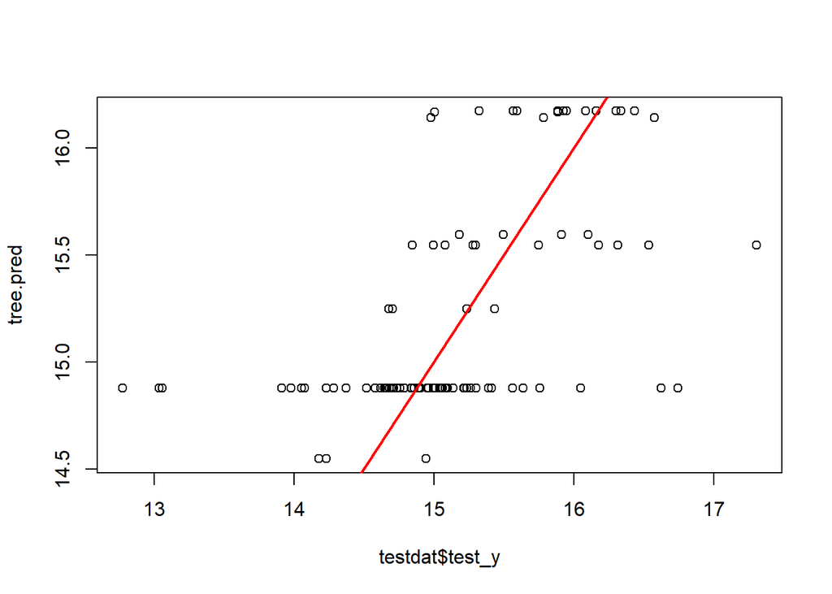

```r
plot(tree.pred ~ testdat$test_y)
abline(a=0, b=1, col="red", lwd=2)
```

```r
cor(tree.pred, testdat$test_y)
```

```
## [1] 0.5634212
```

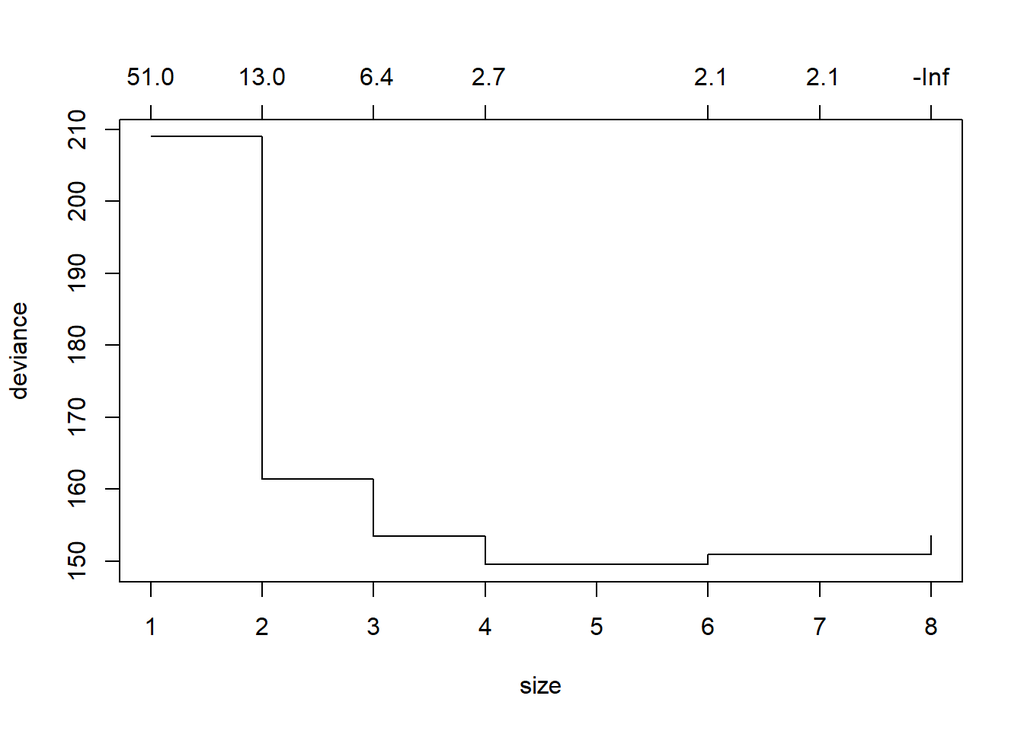

```r
tree.CV <- cv.tree(tree.fit, K=10, FUN=prune.tree)

# Deviance에 대한 plot
plot(tree.CV)
```

```r
tree.CV$size[tree.CV$dev==min(tree.CV$dev)] # deviance를 최소화하는 가지의 개수
```

```
## [1] 4
```

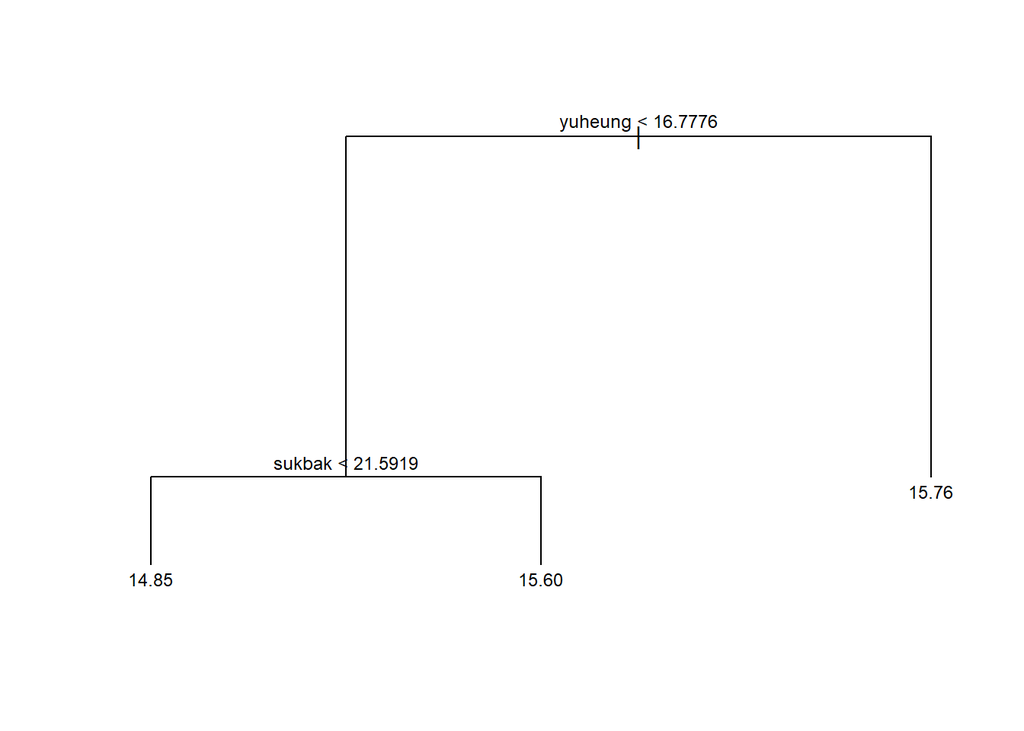

```r
tree.prune <- prune.tree(tree.fit, best=3)
plot(tree.prune)
text(tree.prune, cex=.75)
```

```r
tree.pred2 <- predict(tree.prune, testdat)
mean((tree.pred2 - testdat$test_y)^2)
```

```
## [1] 0.4357781
```

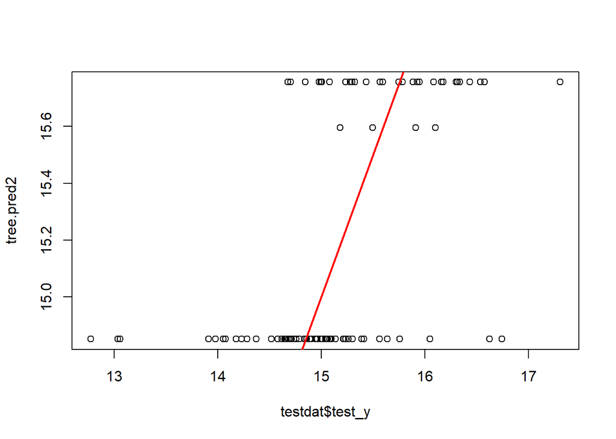

```r
plot(tree.pred2 ~ testdat$test_y)
abline(a=0, b=1, col="red", lwd=2)
```

```r
cor(tree.pred2, testdat$test_y)
```

```
## [1] 0.5432129
```

- rpart library를 이용한 회귀나무 모델

```r
library(rpart)
rpart.fit <- rpart(train_y~., data=traindat, control = rpart.control(cp=0.001))
```

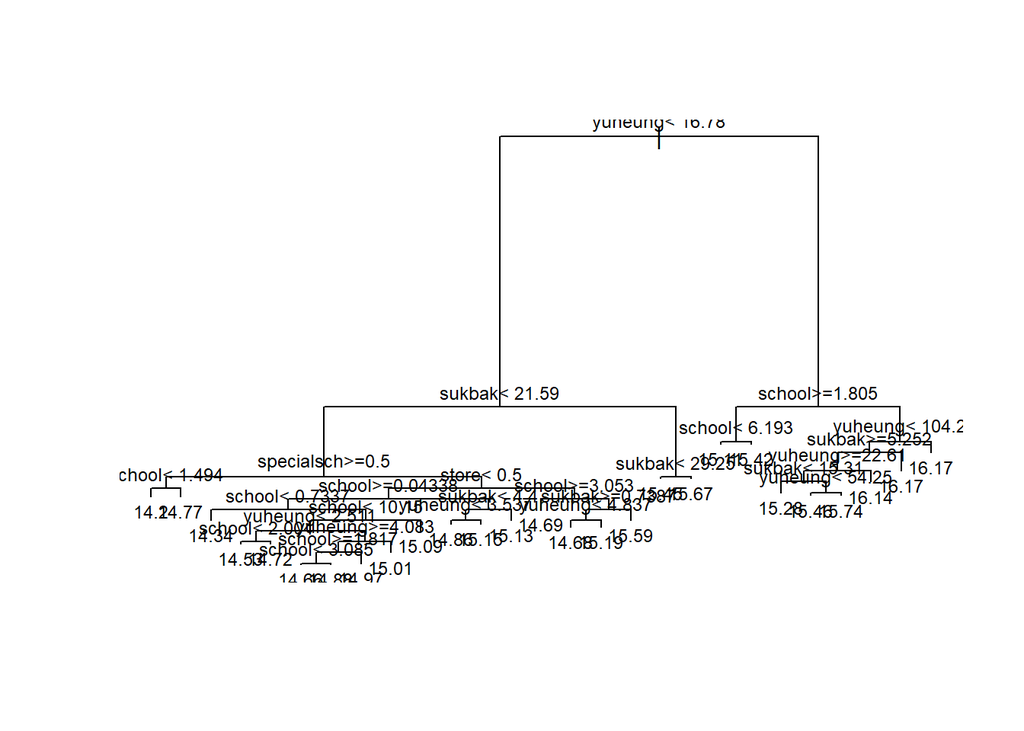

```r
plot(rpart.fit)
text(rpart.fit, cex=.75, pretty=0)
```

```r
pred.rp <- predict(rpart.fit, testdat)
mean((pred.rp - testdat$test_y)^2)
```

```
## [1] 0.4136517
```

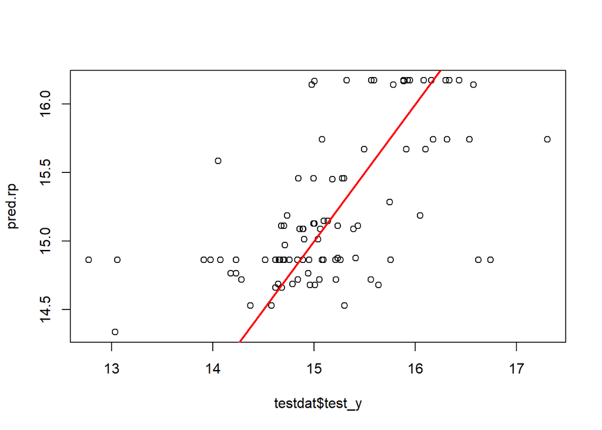

```r
plot(pred.rp ~ testdat$test_y)
abline(a=0, b=1, col="red", lwd=2)
```

```r
cor(pred.rp, testdat$test_y)
```

```
## [1] 0.5868259
```

```r
printcp(rpart.fit)
```

```
##
## Regression tree:
## rpart(formula = train_y ~ ., data = traindat, control = rpart.control(cp = 0.001))
##
## Variables actually used in tree construction:
## [1] school     specialsch store      sukbak     yuheung
##
## Root node error: 207.77/374 = 0.55554
##
## n= 374
##
##           CP nsplit rel error  xerror     xstd
## 1  0.2433863      0   1.00000 1.00604 0.112059
## 2  0.0627896      1   0.75661 0.76924 0.093724
## 3  0.0308902      2   0.69382 0.71855 0.086615
## 4  0.0131210      3   0.66293 0.70106 0.086065
## 5  0.0101440      5   0.63669 0.73827 0.092496
## 6  0.0100548      6   0.62655 0.73612 0.092921
## 7  0.0083703      7   0.61649 0.72492 0.092900
## 8  0.0077445     12   0.57413 0.73391 0.093160
## 9  0.0059077     13   0.56639 0.73132 0.093088
## 10 0.0050885     14   0.56048 0.71375 0.090490
## 11 0.0034122     16   0.55030 0.71133 0.090505
## 12 0.0032933     17   0.54689 0.71610 0.090463
## 13 0.0026241     19   0.54031 0.72402 0.091370
## 14 0.0021790     20   0.53768 0.72915 0.091041
## 15 0.0016849     21   0.53550 0.73091 0.090912
## 16 0.0014027     22   0.53382 0.74162 0.090932
## 17 0.0013789     23   0.53242 0.74107 0.090948
## 18 0.0011378     24   0.53104 0.73746 0.090377
## 19 0.0011029     25   0.52990 0.73516 0.090004
## 20 0.0010000     26   0.52880 0.73516 0.090004
```

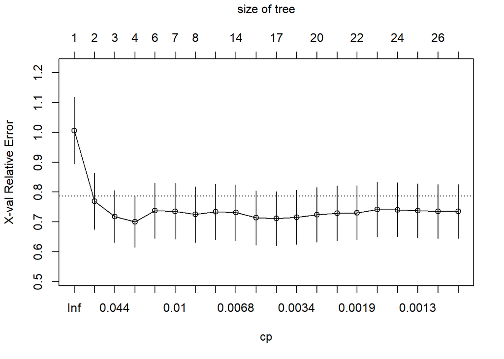

```r
plotcp(rpart.fit)
```

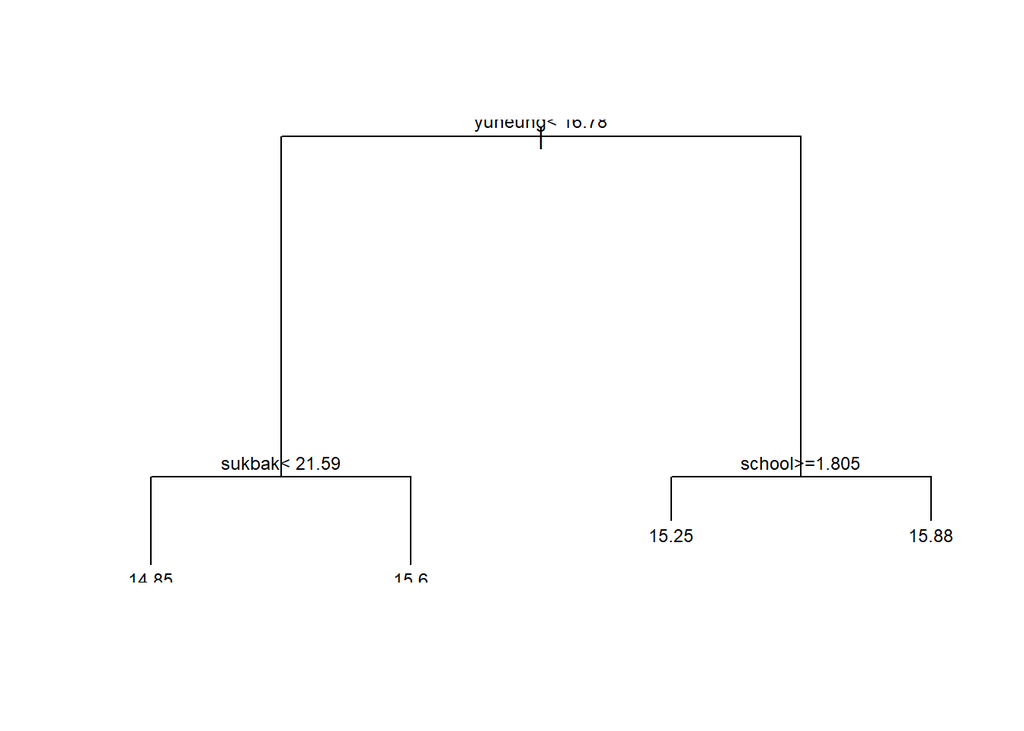

```r
prune.rpart <- prune(rpart.fit, cp=rpart.fit$cptable[which.min(rpart.fit$cptable[,"xerror"]), "CP"])
plot(prune.rpart)
text(prune.rpart, cex=.75, pretty=0)
```

```r
pred.rpart <- predict(prune.rpart, testdat)
mean((pred.rpart - testdat$test_y)^2)
```

```
## [1] 0.4142916
```

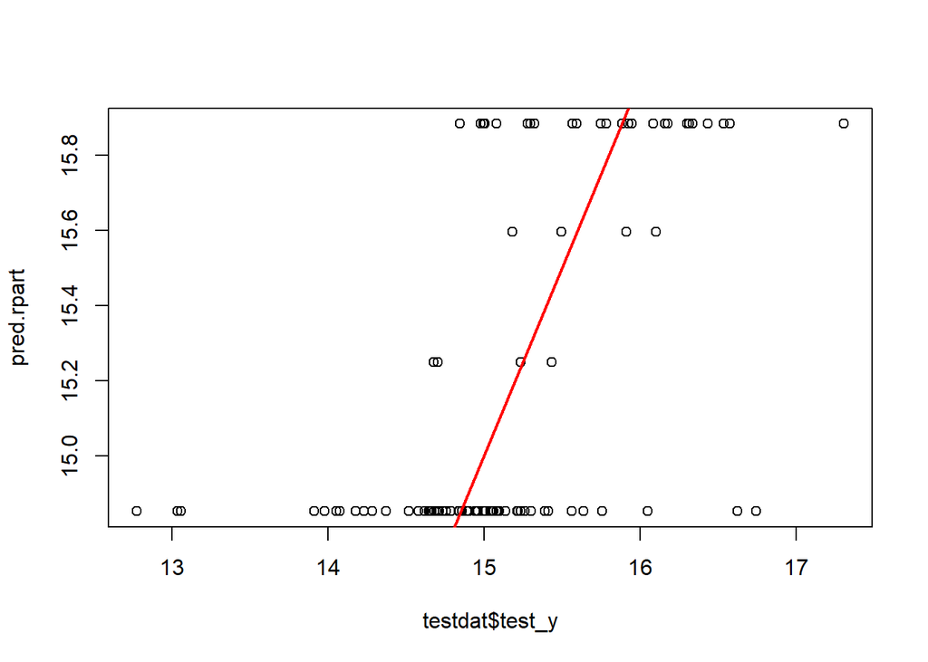

```r
plot(pred.rpart ~ testdat$test_y)
abline(a=0, b=1, col="red", lwd=2)
```

```r
cor(pred.rpart, testdat$test_y)
```

```
## [1] 0.5759312
```

- party library를 이용한 회귀나무 모델

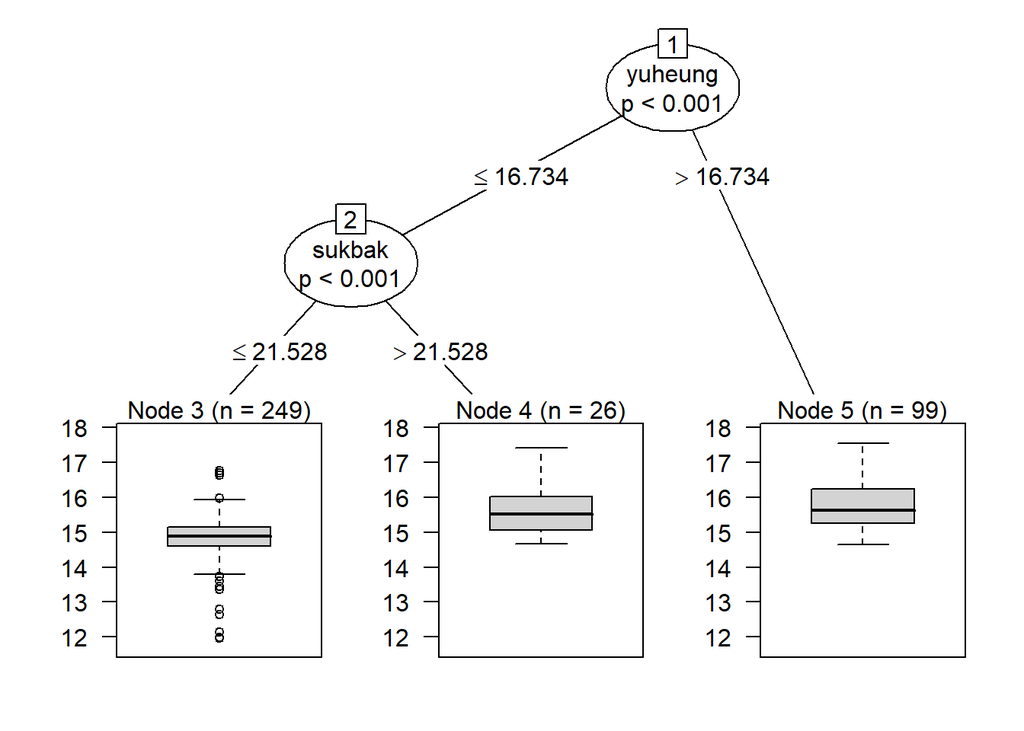

```r
party.fit <- ctree(train_y~., data=traindat)
plot(party.fit)
```

```r
pred.party <- predict(party.fit, testdat)
mean((pred.party-testdat$test_y)^2)
```

```
## [1] 0.4357781
```

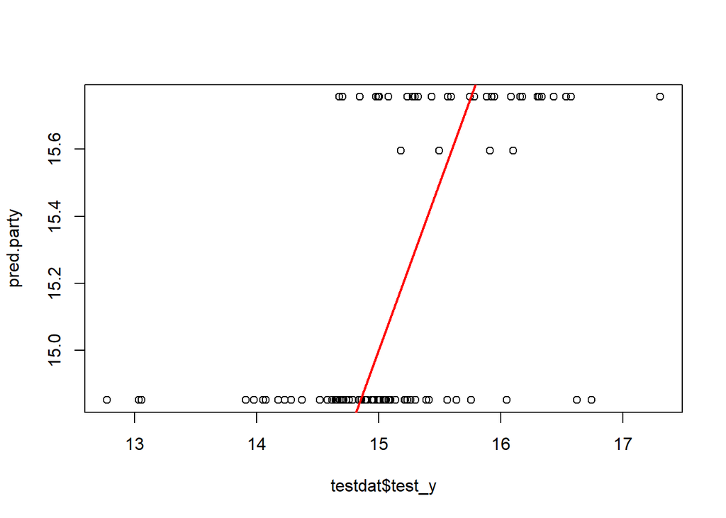

```r
plot(pred.party ~ testdat$test_y)
abline(a=0, b=1, col="red", lwd=2)
```

```r
cor(pred.party, testdat$test_y)
```

```
##              [,1]
## train_y 0.5432129
```

4. KNN (unweighted)
- class library를 이용한 KNN 모델
- 10-fold Cross Validation으로 가장 적합한 K 찾기

```r
library(class)
library(gmodels)
set.seed(1234)
Candidate_k <- seq(from=1, to=29, by=2)
ErrorMat <- matrix(ncol=10, nrow=length(Candidate_k))
foldN <- sample(x=1:10, size=nrow(train_x), replace=T)
CrossTrain_X <- CrossTrain_Y <- CrossTest_X <- CrossTest_Y <- NULL

for(i in 1:10) {
  CrossTrain_X <- train_x[foldN !=i,]
  CrossTest_X <- train_x[foldN ==i,]

  CrossTrain_Y <- train_y[foldN !=i]
  CrossTest_Y <- train_y[foldN ==i]

  for(j in 1:length(Candidate_k)) {
    pred <- knn(train=CrossTrain_X, test=CrossTest_X, cl=CrossTrain_Y, k=Candidate_k[j])
    pred <- as.numeric(pred)
    mse <- mean((CrossTest_Y - pred)^2)

    ErrorMat[j,i] <- mse
  }
}

mean_error <- apply(ErrorMat, 1, mean)
which.min(mean_error)
```

```
## [1] 9
```

- 위에서 계산한 best K를 이용하여 모델 적합

```r
pred_knn <- knn(train=train_x, test=test_x, cl=train_y, k=which.min(mean_error))
pred_knn <- as.numeric(pred_knn)

mse<- mean((pred_knn - test_y)^2)
mse
```

```
## [1] 40600.17
```

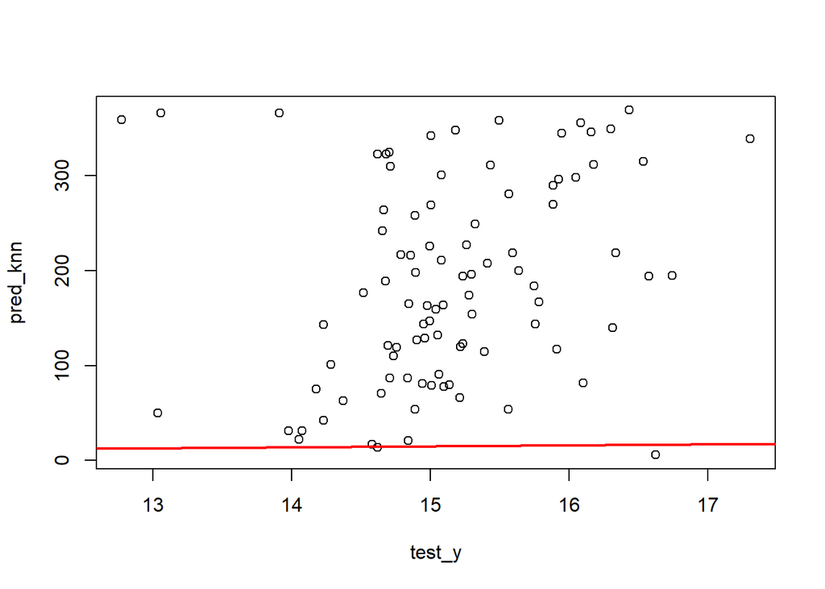

```r
plot(pred_knn ~ test_y)
abline(a=0, b=1, col="red", lwd=2)
```

```r
cor(pred_knn, test_y)
```

```
## [1] 0.25175
```

모델 성능이 좋지 않다. MSE도 크고 예측값과 실제값의 상관관계도 작다. kknn library를 이용하여 새로운 모델을 만들어 본다.

- kknn library를 이용한 KNN
- LOOCV를 이용해 가장 적합한 k 찾기

```r
library(kknn)
LOOCV_kknn2 <- train.kknn(train_y~., traindat, kmax=29, distance=2, kernel="rectangular")
LOOCV_kknn2
```

```
##
## Call:
## train.kknn(formula = train_y ~ ., data = traindat, kmax = 29,     distance = 2, kernel = "rectangular")
##
## Type of response variable: continuous
## minimal mean absolute error: 0.4303639
## Minimal mean squared error: 0.3843668
## Best kernel: rectangular
## Best k: 14
```

```r
kknn_fit3 <- kknn(train_y~., train=traindat, test=testdat,
                  k=23, distance=2, kernel="rectangular")
pred_kknn3 <- fitted(kknn_fit3)

mse4 <- mean((pred_kknn3 - testdat$test_y)^2)
mse4
```

```
## [1] 0.3956944
```

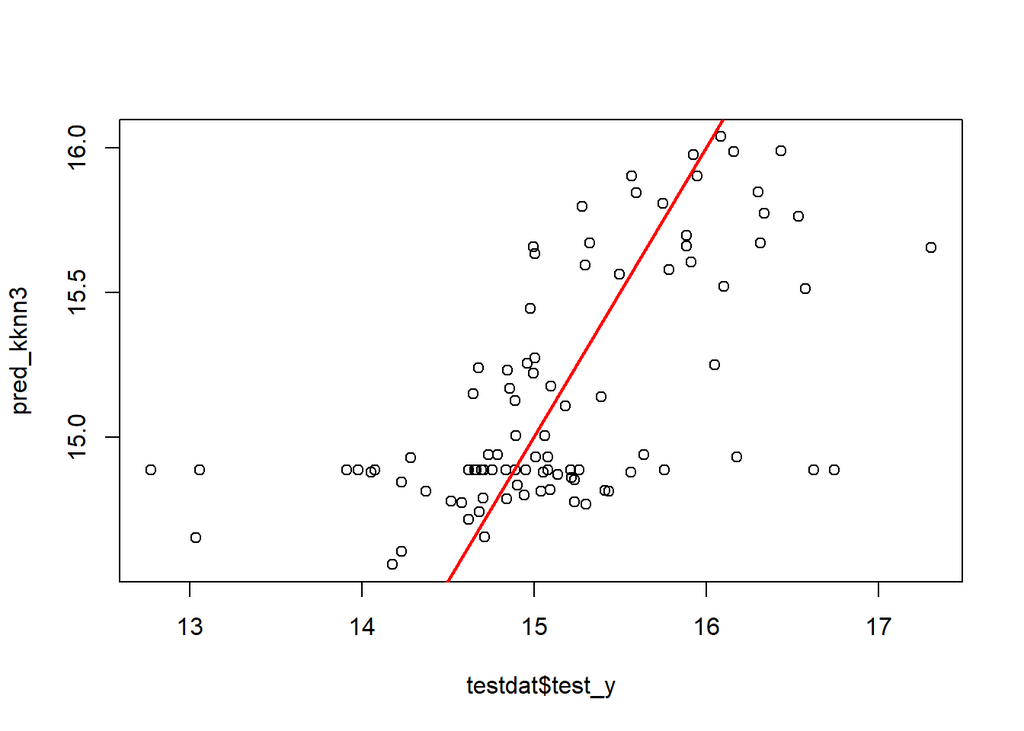

```r
plot(pred_kknn3 ~ testdat$test_y)
abline(a=0, b=1, col="red", lwd=2)
```

```r
cor(pred_kknn3, testdat$test_y)
```

```
## [1] 0.6064379
```

5. KNN (weighted)

```r
kknn_fit <- kknn(train_y~., train=traindat, test=testdat, distance=2, kernel="gaussian")
pred_kknn <- fitted(kknn_fit)

mse2 <- mean((pred_kknn - testdat$test_y)^2)
mse2
```

```
## [1] 0.4800272
```

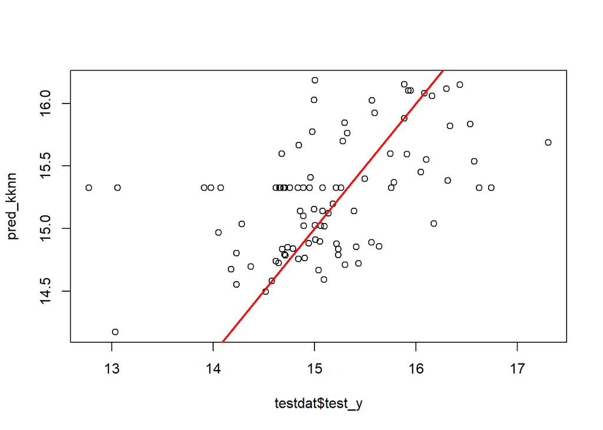

```r
plot(pred_kknn ~ testdat$test_y)
abline(a=0, b=1, col="red", lwd=2)
```

```r
cor(pred_kknn, testdat$test_y)
```

```
## [1] 0.4989405
```

- LOOCV를 이용해 가장 적합한 k 찾기

```r
LOOCV_kknn <- train.kknn(train_y~., traindat, kmax=29, distance=2, kernel="gaussian")
LOOCV_kknn
```

```
##
## Call:
## train.kknn(formula = train_y ~ ., data = traindat, kmax = 29,     distance = 2, kernel = "gaussian")
##
## Type of response variable: continuous
## minimal mean absolute error: 0.4307621
## Minimal mean squared error: 0.3836458
## Best kernel: gaussian
## Best k: 14
```

```r
kknn_fit2 <- kknn(train_y ~., train=traindat, test=testdat,
                  k=23, distance=2, kernel="gaussian")
pred_kknn2 <- fitted(kknn_fit2)

mse3 <- mean((pred_kknn2 - testdat$test_y)^2)
mse3
```

```
## [1] 0.3979059
```

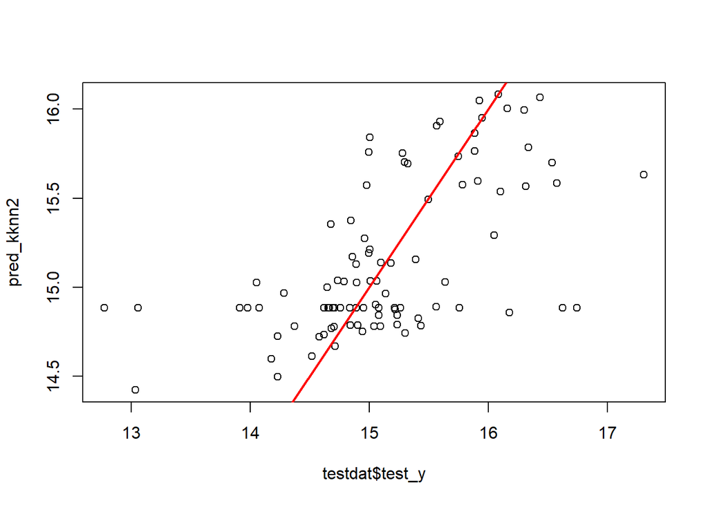

```r
plot(pred_kknn2 ~ testdat$test_y)
abline(a=0, b=1, col="red", lwd=2)
```

```r
cor(pred_kknn2, testdat$test_y)
```

```
## [1] 0.5982026
```

5. 앙상블을 이용한 모델 향상
1. Bagging

Bagging을 이용하여 모델을 향상시켰습니다.

```r
library(ipred)
bagging.fit <- ipred::bagging(train_y~., data=traindat, nbagg=1000)

pred.bagging <- predict(bagging.fit, testdat)
mean((pred.bagging-testdat$test_y)^2)
```

```
## [1] 0.3921872
```

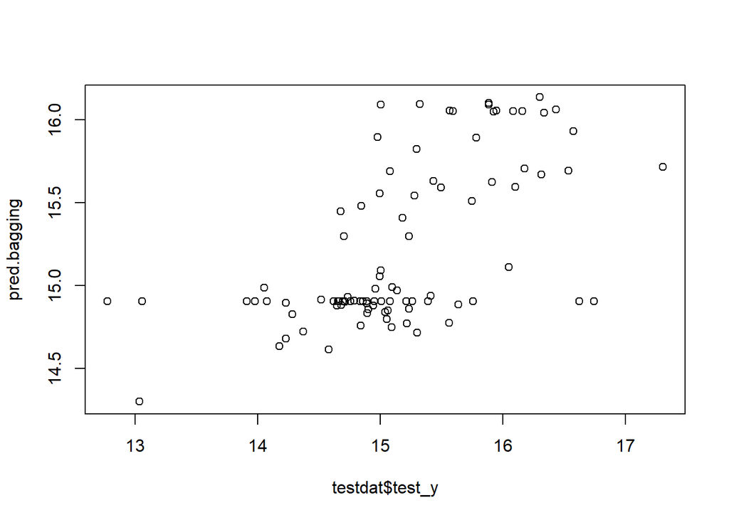

```r
plot(pred.bagging~testdat$test_y)
```

2. Boosting

```r
library(mboost)
boosting.fit <- glmboost(train_y~., data=traindat)

pred.boosting <- predict(boosting.fit, testdat)
mean((pred.boosting-testdat$test_y)^2)
```

```
## [1] 0.5099428
```

3. Random Forest

Random Forest를 사용하여 모델을 향상시켰습니다.

```r
library(randomForest)
```

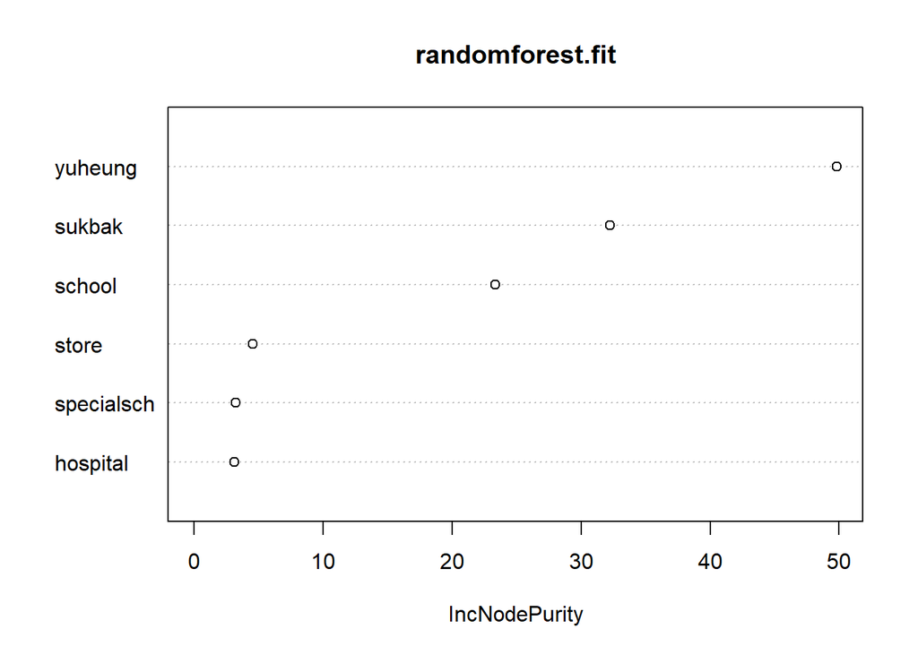

```r
randomforest.fit <- randomForest(train_y~., data=traindat)
varImpPlot(randomforest.fit) # Accuracy를 높이는데 중요한 변수와 gini계수를 줄이는데 중요한 변수
```

```r
pred.randomforest <- predict(randomforest.fit, testdat)
mean((pred.randomforest-testdat$test_y)^2)
```

```
## [1] 0.3987069
```